# Ford GoBike System Data

## by Kareim Hassanin

# Ford GoBike System Data

## Introduction

> This data set includes information about individual rides made in a bike-sharing system covering the greater San Francisco Bay area. The Bikeshare.com website and platform is owned and managed by Cyclehop, a private bike share company

### 1- Investigation of trip duration:

##### The time of each trip is investigated to understand its behaviour. We used Histogram to devide the time into slots for better understanding of the data.

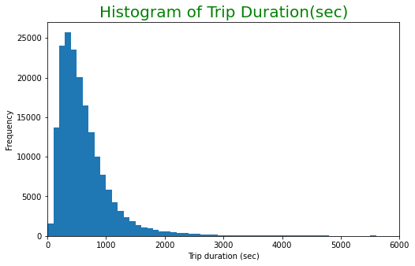

```python
# Histogram of trip duration in sec
bins = np.arange(0, df_cleaned['duration_sec'].max() + 100 , 100)
plt.figure(figsize=[8, 5])
plt.title('Histogram of Trip Duration(sec)', fontsize=20, y=1.0, color="green")
plt.hist(df_cleaned["duration_sec"], bins = bins)
plt.xlabel('Trip duration (sec)')
plt.ylabel('Frequency')
plt.xlim((0, 6000))
plt.show();
```

### 2- Investigation of age of the members:

##### The age of each trip user is investigated to understand its variation. We used Histogram to devide the age of users into slots for better understanding of the data.

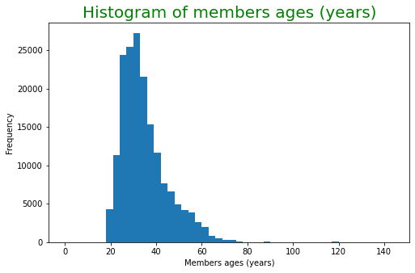

```python
# check the histogram of the members ages
bins = np.arange(0, df_cleaned['member_age'].max() + 5 , 3)
plt.figure(figsize=[8, 5])
plt.title('Histogram of members ages (years)', fontsize=20, y=1.0, color="green")
plt.hist(df_cleaned["member_age"], bins=bins)
plt.xlabel('Members ages (years)')
plt.ylabel('Frequency')
plt.show();
```

### 3- Investigation of member genders:

##### The gender of each trip user is investigated to understand its variation. We used pie chart to illustrate the gender of users for better understanding of the data.

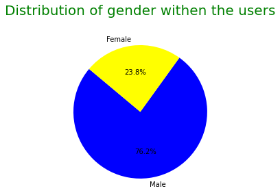

```python
# Data to plot using pie chart
labels = member_gender["index"]
sizes = member_gender["member_gender"]
colors = ['blue', 'yellow']
explode = (0, 0)  # explode 1st slice
plt.title('Distribution of gender withen the users', fontsize=20, y=1.12, color="green")

# Plot
plt.pie(sizes, explode=explode, labels=labels, colors=colors,
autopct='%1.1f%%', shadow=False, startangle=140)

plt.axis('equal')
plt.show()
```

### Most of the trips user are males.

### 4- Investigation of start stations:

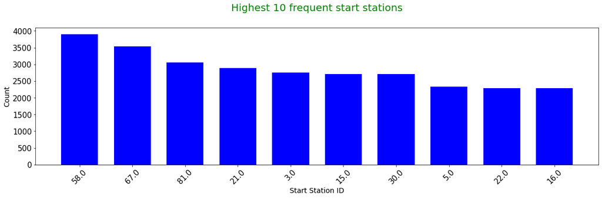

```python
# plot the end_stations_highest_10
plt.figure(figsize=[20, 5])
plt.bar(Start_stations_highest_10['start_station_id'], Start_stations_highest_10['start_station_count'],
        color='blue', width=0.7)
plt.title('Highest 10 frequent start stations', fontsize=20, y=1.1, color="green")
plt.xlabel('Start Station ID', fontsize=14)
plt.ylabel('Count', fontsize=14)
plt.xticks(rotation=45, fontsize=15)
plt.yticks(fontsize=15)
plt.show();
```

### Stations 58, 67, 81, 21, 3, 15, 30, 5, 22, 16 are the highest 10 start stations used.

### 5- Investigation of end stations:

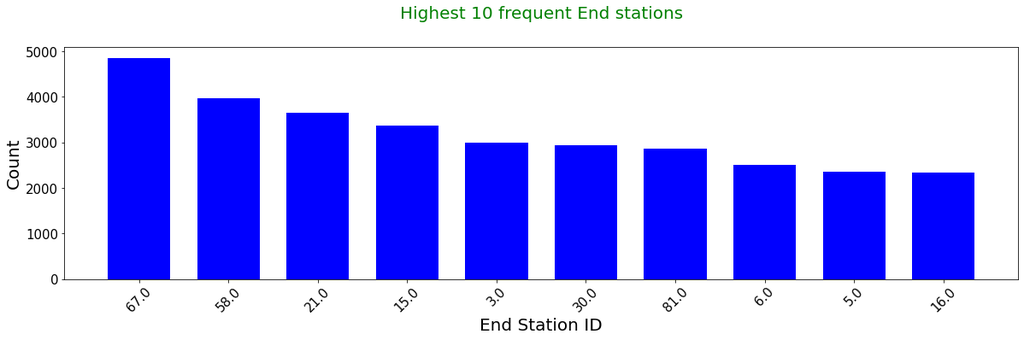

```python
# plot the end_stations_highest_10
plt.figure(figsize=[20, 5])
plt.bar(end_stations_highest_10['end_station_id'], end_stations_highest_10['end_station_count'], color='blue', width=0.7)
plt.title('Highest 10 frequent End stations', fontsize=20, y=1.1, color="green")
plt.xlabel('End Station ID', fontsize=20)
plt.ylabel('Count', fontsize=20)
plt.xticks(rotation=45, fontsize=15)
plt.yticks(fontsize=15)
plt.show();
```

### Stations 67, 58, 21, 15, 3, 30, 81, 6, 5, 16 are the highest 10 end stations used.

### 6- Investigation of user type:

##### For all trips, which are the most common user type?

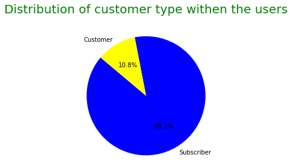

```python
# Data to plot using pie chart
labels = user_type["index"]
sizes = user_type["user_type"]
colors = ['blue', 'yellow']
explode = (0, 0)  # explode 1st slice
plt.title('Distribution of customer type withen the users', fontsize=20, y=1.1, color="green")

# Plot
plt.pie(sizes, explode=explode, labels=labels, colors=colors,
autopct='%1.1f%%', shadow=False, startangle=140)

plt.axis('equal')
plt.show()
```

### The most common user type who use the app is subscribers.

### 7- Investigation of correlations between the trip duration and the age of members:

##### For all trips, Is the age of the user have effect on the duration of the trip? What is the nature of this effect?

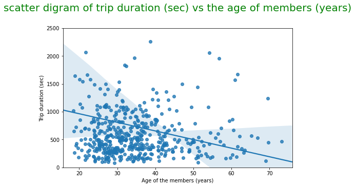

```python
# scatter digram of trip duration in sec vs the age of members (less points)
plt.figure(figsize=[8, 5])
plt.title('scatter digram of trip duration (sec) vs the age of members (years)', fontsize=20, y=1.1, color="green")
sb.regplot(x=sample_corr["member_age"], y=sample_corr["duration_sec"], truncate=False, x_jitter=0.5)
plt.xlabel('Age of the members (years)')
plt.ylabel('Trip duration (sec)')
plt.ylim([0,2500])
plt.show();
```

### 8- Investigation of correlations between the trip duration and the gender of users:

##### For all trips, Is the gender of the user have effect on the duration of the trip? What is the nature of this effect?

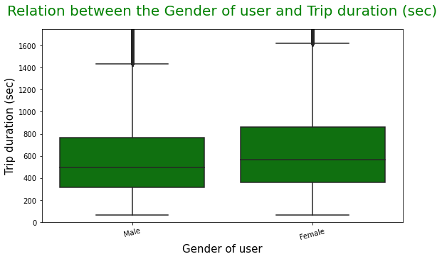

```python
# use box plot
plt.figure(figsize=[20, 5])
plt.subplot(1, 2, 2)
sb.boxplot(data=member_gender_without_others, x='member_gender', y='duration_sec', color='green')
plt.title('Relation between the Gender of user and Trip duration (sec)', fontsize=20, y=1.05, color="green")
plt.xlabel('Gender of user', fontsize=15)
plt.ylabel('Trip duration (sec)', fontsize=15)
plt.xticks(rotation=15);
plt.ylim([0,1750]);
```

### The trip duration tend to be a little longer for females than males (males tend to be faster).

### 9- Investigation of correlations between the user type and user age:

##### For all trips, Is the age of the user have effect on the selecting the user type of the trip? What is the nature of this effect?

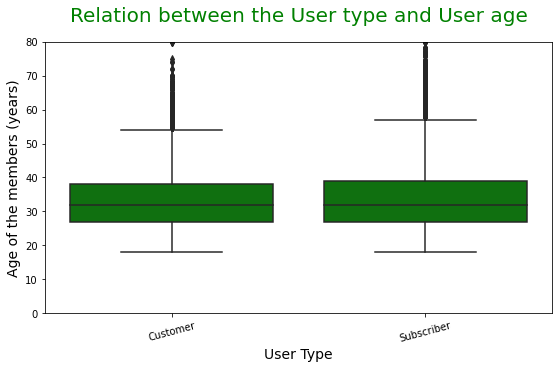

```python
# use box plot
plt.figure(figsize=[20, 5])
plt.subplot(1, 2, 2)
sb.boxplot(data=df_cleaned, x='user_type', y='member_age', color='green')
plt.title('Relation between the User type and User age', fontsize=20, y=1.05, color="green")
plt.xlabel('User Type', fontsize=14)
plt.ylabel('Age of the members (years)', fontsize=14)
plt.xticks(rotation=15);
plt.ylim([0,80]);
```

### The age of the user have no effect on the user type.

### 10- Investigation of correlations between the user gender and user type:

##### For all trips, Is the gender of the user have effect on the selecting the user type of the trip? What is the nature of this effect?

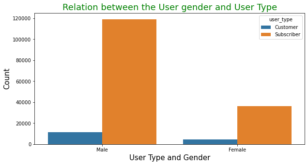

```python
# Clustered bar chart
plt.figure(figsize=[10, 5])
sb.countplot(data = member_gender_without_others, x = 'member_gender', hue = 'user_type')
plt.title('Relation between the User gender and User Type', fontsize=18, y=1.0, color="green")
plt.xlabel('User Type and Gender', fontsize=15)
plt.ylabel('Count', fontsize=15);
```

### Males tend to to use the customer account type much more the females

### 11- Investigation of correlations between the user gender and user age:

##### For all trips, Is the gender of the user and the user age of the trip are linked together? What is the nature of this effect?

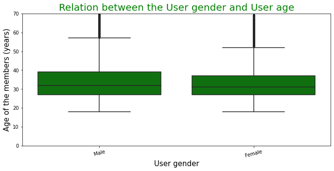

```python
# Boxplot
plt.figure(figsize=[25, 5])
plt.subplot(1, 2, 2)
sb.boxplot(data=member_gender_without_others, x='member_gender', y='member_age', color='green')
plt.title('Relation between the User gender and User age', fontsize=20, y=1.0, color="green")
plt.xlabel('User gender', fontsize=15)
plt.ylabel('Age of the members (years)', fontsize=15)
plt.xticks(rotation=15);
plt.ylim([0,70]);
```

### Males with older age tend to use the app than the females.

### 12- Investigation of Age, gender of the users and the trip duration:

##### Is the age and gender of the user have effect on the trip duration? What is the nature of this effect?

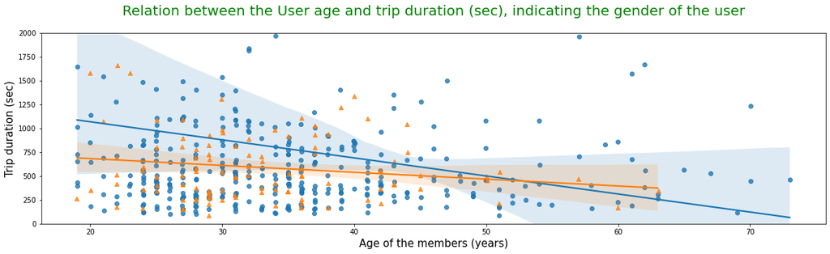

```python
# Create markers for gender and plot the scatter plot
gender_marker = [['Male', 'o'], ['Female', '^']]
plt.figure(figsize=[20, 5])


for gender, marker in gender_marker:
    plot_data = sample.loc[sample['member_gender'] == gender]
    sb.regplot(data = plot_data, x = 'member_age', y = 'duration_sec', x_jitter = 0.04, marker = marker)
    plt.title('Relation between the User age and trip duration (sec), indicating the gender of the user', fontsize=20, y=1.07, color="green")
    plt.xlabel('Age of the members (years)', fontsize=15)
    plt.ylabel('Trip duration (sec)', fontsize=15)
    plt.ylim([0,2000]);
```

### 13- Investigation of user type, gender of the users and the trip duration:

##### Is the user type and gender of the user have effect on the trip duration? What is the nature of this effect?

[output not shown]

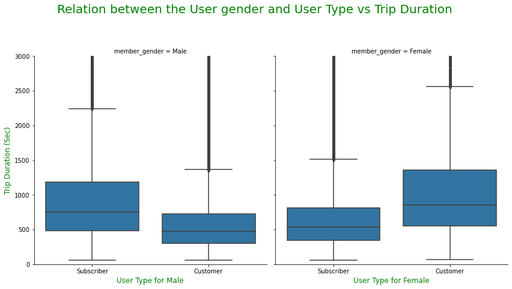

```python
# drow FacetGrid
g = sb.FacetGrid(data = member_gender_without_others, col = 'member_gender', size = 6,  margin_titles=True)
g.map(sb.boxplot, 'user_type', 'duration_sec')
g.axes[0,0].set_xlabel('User Type for Male', fontsize=12, y=1.1, color="green")
g.axes[0,1].set_xlabel('User Type for Female', fontsize=12, y=1.1, color="green")
g.axes[0,0].set_ylabel('Trip Duration (Sec)', fontsize=12, color="green")

plt.ylim([0,3000]);


# relplot is a nice organized way to use it

g.fig.subplots_adjust(top=0.9) # adjust the Figure in rp
g.fig.suptitle('Relation between the User gender and User Type vs Trip Duration', fontsize=20, y=1.1, color="green");
```

### Subcribers males take longer trip durations than females, while the female customers take longer trip durations than males

### 14- Investigation of user type, gender of the users and the start time of the trip:

##### Is the user type and gender of the user have effect on the trip start time? What is the nature of this effect?

```python
# create new dataframe to preserve the original data
data = member_gender_without_others
# create column to show the time in hour format
data["Hour"] = data["start_time"].dt.hour
```

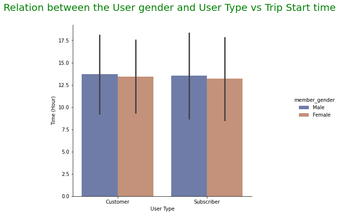

```python
# Draw a nested barplot by species and sex
g = sb.catplot(
    data=data, kind="bar",
    x='user_type', y="Hour", hue="member_gender",
    ci="sd", palette="dark", alpha=.6, height=6
)

g.set_axis_labels("User Type", "Time (Hour)")
g.fig.subplots_adjust(top=0.9) # adjust the Figure in rp
g.fig.suptitle('Relation between the User gender and User Type vs Trip Start time', fontsize=20, y=1.0, color="green");
```

### There is no diffrence between the user types of both males and females in the trip start time

### Data Analysis Summary:

#### 3- Most of the trips user are males.

#### 4- Stations 58, 67, 81, 21, 3, 15, 30, 5, 22, 16 are the highest 10 start stations used.

#### 5- Stations 67, 58, 21, 15, 3, 30, 81, 6, 5, 16 are the highest 10 end stations used.

#### 6- The most common user type who use the app is subscribers.

### Data Analysis Summary:

#### 8- The trip duration tend to be a little longer for females than males (males tend to be faster).

#### 9- The age of the user have no effect on the user type.

#### 10- Males tend to to use the customer account type much more the females.

#### 11- Males with older age tend to use the app than the females.

### Data Analysis Summary:

#### 13- Subcribers males take longer trip durations than females, while the female customers take longer trip durations than males

#### 14- There is no diffrence between the user types of both males and females in the trip start time